# Lab 2 Individual 2

Dongming Li

9/10/2020

# Searching for the Best Chocolates

1. How are the ratings distributed? Create both a histogram and a boxplot and describe them. Don’t forget to mention outliers, if there are any.

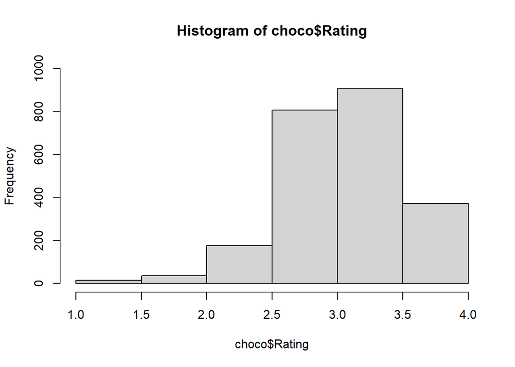

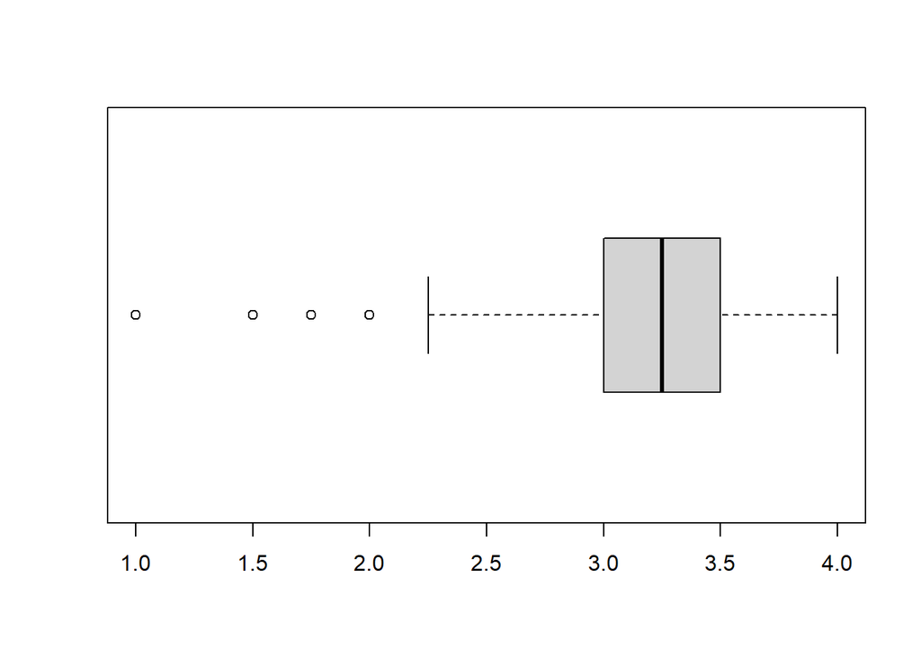

[output not shown]

2. How does the number of ratings depend on the year? Draw a bar chart of the number of reports.

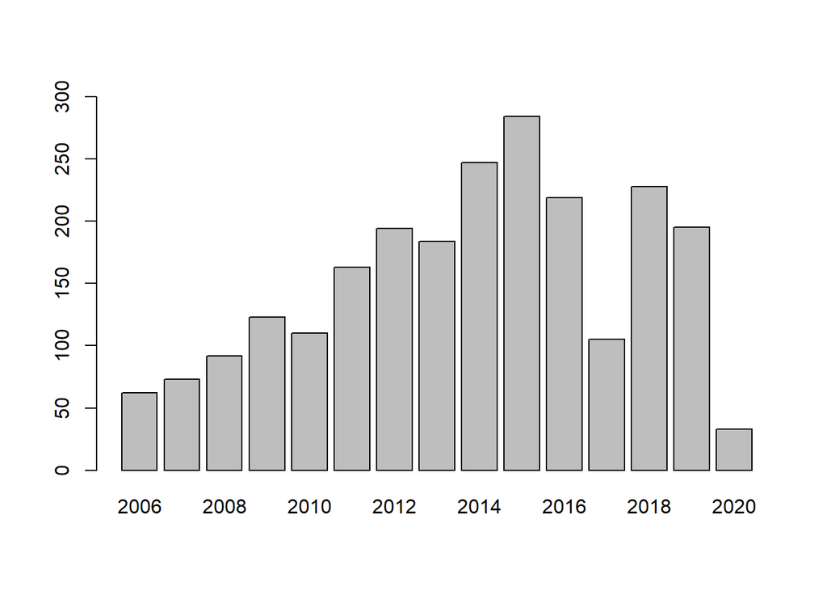

3. Do ratings depend on the cacao percentage of a chocolate bar? Create both numerical and graphical summaries, and explain.

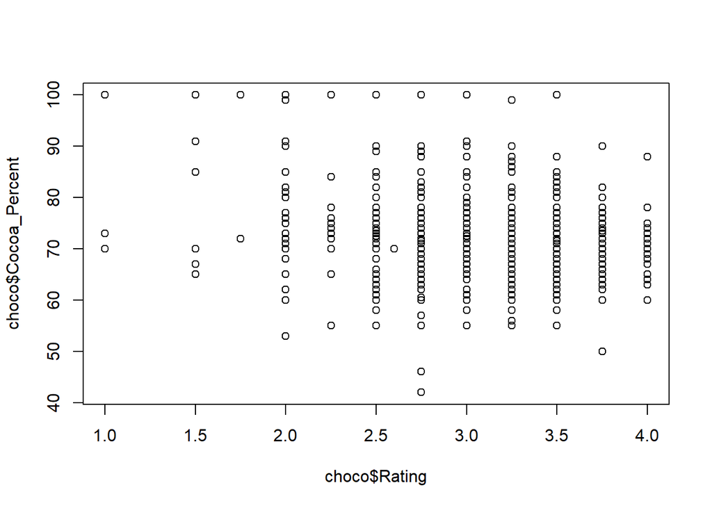

```r
plot(choco$Rating,choco$Cocoa_Percent)
```

```r
cor(choco$Rating, choco$Cocoa_Percent)
```

```
## [1] -0.1510178
```

[output not shown]

4. How do different characteristics of the chocolate compare? To elaborate, which characteristics tend to be more favorable and which ones are not? Create both numerical and graphical summaries, and explain.

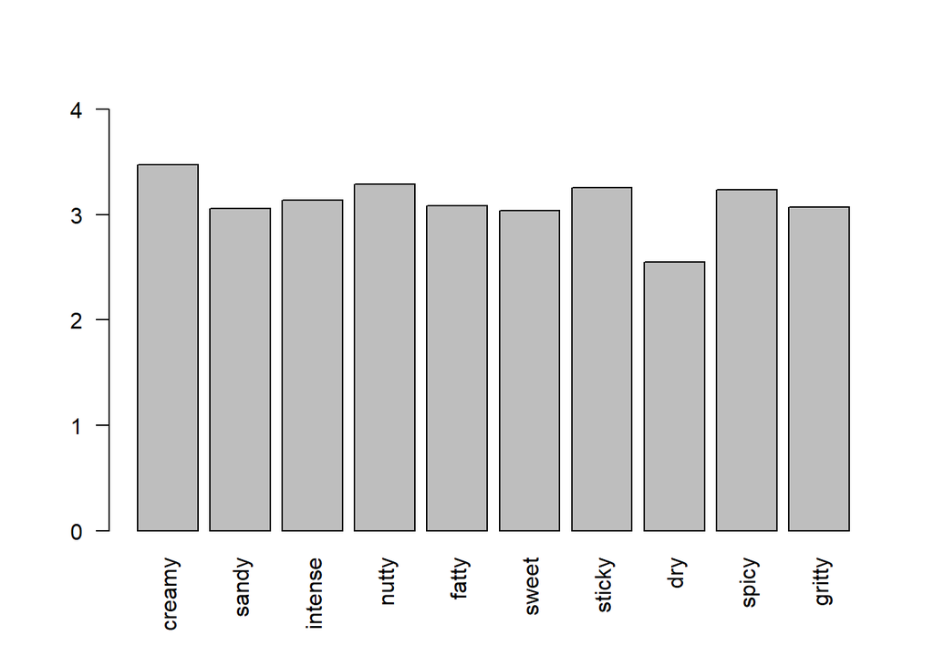

```
##   creamy    nutty   sticky    spicy  intense    fatty   gritty    sandy
## 3.469856 3.285909 3.252778 3.234968 3.135814 3.082968 3.071023 3.059039
##    sweet      dry
## 3.034356 2.548491
```

[output not shown]

5. Brainstorm two analyses you would like to perform with your teammate. Describe in plain language what comparisons are you making. Create suitable numerical and graphical summaries for your analyses. Describe the results.

   I plan to analyze the relationship between chocolate bean origin and rating together with my teammates to find out the best chocolate bean origin.In addition, the relationship between brands and ratings of all chocolate companies is studied to identify the best chocolate companies.The detailed analysis will be shown in team.Rmd.